# Introduction to Statistics

Bennett Kleinberg

Week 7

## Week 7

- Part 1: Dependent (repeated) measures
- Part 2: The t-statistic for dependent (repeated) measures
- Part 3: Hypothesis testing with repeated measures

Part 1: Dependent (repeated) measures

## t-tests so far

Allows us to deal with the missing $\sigma$ (we just estimate the standard error)

**One sample t-test:** $t=\frac{M-\mu}{s_M}$ with $s_M = \sqrt{\frac{s^2}{n}}$ and $df=n-1$

**Independent t-test:** $t=\frac{(M_1-M_2)-(\mu_1-\mu_2)}{s_{M_1-M_2}}$ with $s_{M_1-M_2} = \sqrt{{\frac{s_p^2}{n_1}+\frac{s_p^2}{n_2}}}$ with $s_p^2 = \frac{df_1*s^2_1+df_2*s^2_2}{df_1+df_2}$ and $df=n_1+n_2-2$

## General logic

1. Define hypotheses (always: null + alternative)
2. Determine $\alpha$
3. Find critical values
4. Calculate $t$
5. Make a decision

## Between vs within subjects designs

We can compare 2 groups in different ways:

- two groups of different people
  - e.g. one group with espresso intake, one group without
  - these are **between-subjects designs**
  - you are in one or the other

## Between vs within subjects designs

We can compare 2 groups in different ways:

- two groups measurements of the group people
  - e.g. one group is tested at moment A and at moment B
  - these are **within-subjects designs**
  - we only have one group but *repeated* measures

This is our focus for today!

*Think for a second: what does this mean statistically?*

## Scenario

We’re interested in how a year in the pandemic affected peoples outlook on the future.

- we have a sample of $n=30$
- and measured the *outlook on the future* on a 9-point scale (1-very bad, 9-very good)
- we measured this at two points in time:
  - June 2019 ($time_1$)
  - June 2020 ($time_2$)

*Important: it’s the same 30 people at both measurement moments!*

## Our data

June 2019:

$M_{time_1} = 5.14$ and $SD_{time_1}=0.96$

June 2020:

$M_{time_2} = 3.65$ and $SD_{time_2}=2.68$

Did the time in the pandemic affect people’s outlook on the future?

## What is happening here?

We are now talking about **2 measurements of the same people**:

| id | $time_1$ | $time_2$ |
| --- | --- | --- |
| 1 | 3 | 1 |
| 2 | 6 | 3 |
| 3 | 9 | 2 |

## Change = difference score

| id | $time_1$ | $time_2$ | $\Delta$ |
| --- | --- | --- | --- |
| 1 | 3 | 1 | -2 |
| 2 | 6 | 3 | -3 |
| 3 | 9 | 2 | -7 |

$M_{\Delta} = \frac{(-2) + (-3) +(-7)}{3} = -4.00$

$SS_{\Delta} = \sum{(X-M)^2} = 14.00$

## Difference to between-subjects design

The alternative would be a between-subjects design:

e.g. $n_1=3$ at $time_1$ and $n_2=3$ at $time_2$

| id | score | time |
| --- | --- | --- |
| 1 | 3 | 1 |
| 2 | 6 | 1 |
| 3 | 9 | 1 |
| 4 | 1 | 2 |
| 5 | 3 | 2 |
| 6 | 2 | 2 |

## Statistical difference

| id | score | time |
| --- | --- | --- |
| 1 | 3 | 1 |
| 2 | 6 | 1 |
| 3 | 9 | 1 |
| 4 | 1 | 2 |
| 5 | 3 | 2 |
| 6 | 2 | 2 |

$M_1 = 6.00$ and $M_2 = 2.00$

$SS_1 = 18.00$ and $SS_2 = 2.00$

## Statistical difference

Within-subjects:

$M_{\Delta} = -4.00$, $SS_{\Delta} = 14.00$, $s^2_{\Delta} = \frac{14.00}{2} = 7$

$SE = \sqrt{\frac{7}{3}} = 1.53$, $t=2.63$

## Statistical differences

Between-subjects:

$M_1 = 6.00$, $SS_1 = 18.00$, $M_2 = 2.00$, $SS_2 = 2.00$

$s^2_p = \frac{SS_1+SS_2}{df_1+df_2} = \frac{20}{4}=5$

$SE = \sqrt{\frac{5}{3}+\frac{5}{3}} = 1.83$, $t=2.19$

## Benefits of repeated measures

- effective halves your sample size (for the same effect)
- hence more power (more in Week 10)
- eliminates individual differences between samples
- allows for baselining
- longitudinal designs possible (with more confidence in causal effects)

## Problems of repeated measures

- participant loss (in longitudinal designs)
- other factors play a role (order effects)
- sometimes practically difficult

Part 2: The t-statistic for dependent (repeated) measures

## Our data

Outlook on the future:

June 2019:

$M_{time_1} = 5.14$ and $SD_{time_1}=0.96$

June 2020:

$M_{time_2} = 3.65$ and $SD_{time_2}=2.68$

## Research question

Typically: did treatment A affect variable B?

Here: the COVID-19 pandemic is the “treatment”

- $time_1$: no pandemic on people’s minds
- $time_2$: during the pandemic

Did the time in the pandemic affect people’s outlook on the future?

## Hypotheses

We are interested in the difference between measurement moments:

**we effectively reduce the problem to a one-sample problem**

We have one sample with the **difference $\Delta$** of interest.

## We know the one-sample case

*All hypotheses are now about the difference score!*

$H_0: \mu_D=0$ (there is no difference between the two time points)

- (directional 1) $H_1: \mu_D>0$ (note we can be more specific about $H_0: \mu_D\leq0$)
- (directional 2) $H_1: \mu_D<0$ (note we can be more specific about $H_0: \mu_D\geq0$)
- (non-directional) $H_1: \mu_D \neq 0$

## The t-statistic

The structure of $t$ remains the same: $t=\frac{M-\mu}{s_{M}}$

But now for the difference $D$ (or $\Delta$)

$t=\frac{(M_D-\mu_D)}{s_{M_{D}}}$

And what about the *standard error*?

## The standard error

The one-sample case: $s_{M} = \frac{s}{\sqrt{n}}$

Only difference: we are now talking about the $\Delta$ term.

So: $s_{M_{D}} =$ estimated standard error of the difference.

## Typical reporting

|  | $time_1$ | $time_2$ | $\Delta$ |
| --- | --- | --- | --- |
| M | 5.14 | 3.65 | -1.49 |
| SD | 0.96 | 2.68 | 1.30 |

**Important**: $SD_{\Delta}$ is the standard deviation of the difference. Not the difference in standard deviations!

## $SD$ of $\Delta$

| id | $time_1$ | $time_1$ | $\Delta$ |
| --- | --- | --- | --- |
| 1 | 3 | 1 | -2 |
| 2 | 6 | 3 | -3 |
| 3 | 9 | 2 | -7 |
| $M$ | 6.00 | 2.00 | -4.00 |
| $SD$ | 3.00 | 1.00 | 2.65 |

## Degrees of freedom

We have only one group of participants (i.e. just $n$).

So: $df = n-1$

## SE for the difference

$s_{M_{D}} = \sqrt{\frac{s^2_{\Delta}}{n}} = \frac{s_{\Delta}}{\sqrt{n}}$

Here:

$s_{\Delta}=1.30$

So:

$s_{M_{D}} = \frac{s_{\Delta}}{\sqrt{n}}=\frac{1.30}{\sqrt{30}}=0.24$

Part 3: Hypothesis testing with repeated measures

## Steps

1. Hypotheses
2. Alpha level
3. Degrees of freedom
4. Critical t-values
5. Collecting data
6. Calculating $t$
7. Making a decision

## Hypotheses

Scenario: *We’re interested in how a year in the pandemic affected peoples outlook on the future*

$H_0: \mu_{D} = 0$

$H_1: \mu_{D} \neq 0$

## Alpha level

We choose $\alpha = 0.01$

*Note: we have a two-tailed hypothesis, so all “unlikeliness” is spread to the two tails.*

## Degrees of freedom

Only one group:

$df = n-1=30-1=29$

## Critical t-values region

We know the df: $df=29$ and two-tailed $\alpha=0.01$

Critical t-values: $t = \pm 2.756$

This is the critical value that demarcates the region *in both tails combined* that makes up an area of $\alpha = 0.01$ (1%).

## Critical region

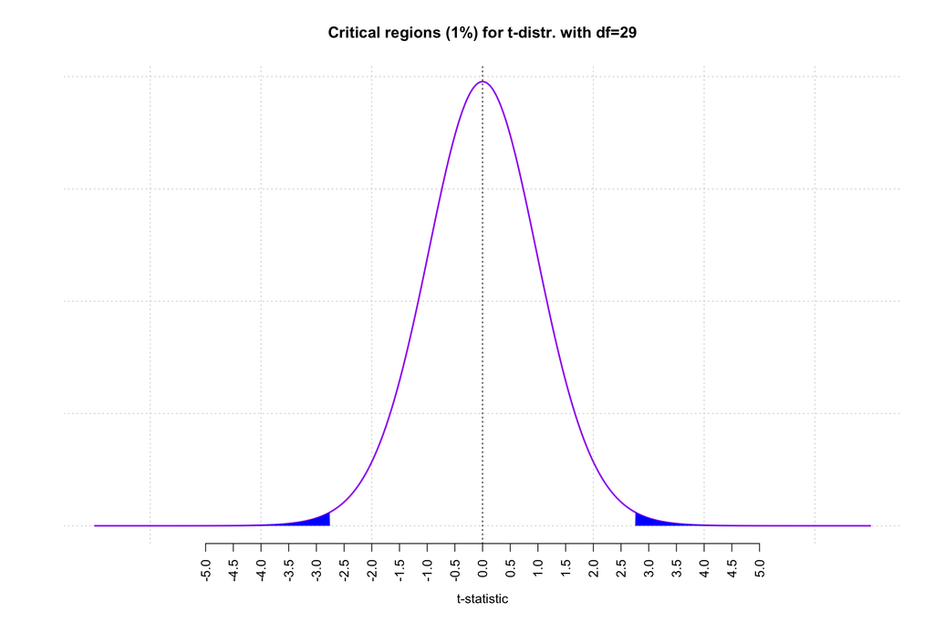

## Collecting the data

|  | $time_1$ | $time_2$ | $\Delta$ |
| --- | --- | --- | --- |
| M | 5.14 | 3.65 | -1.49 |
| SD | 0.96 | 2.68 | 1.30 |

## Calculating t

We know: $t=\frac{(M_D-\mu_D)}{s_{M_{D}}}$

And: $s_{M_{D}} = \sqrt{\frac{s^2_{\Delta}}{n}} = \frac{s_{\Delta}}{\sqrt{n}}$

## For our data

Standard error of the difference score:

$s_{M_{D}} = \frac{s_{\Delta}}{\sqrt{n}}=\frac{1.30}{\sqrt{30}}=0.24$

t-value:

$t=\frac{(-1.49-0)}{0.24}=\frac{-1.49}{0.24}=-6.21$

## Locating t

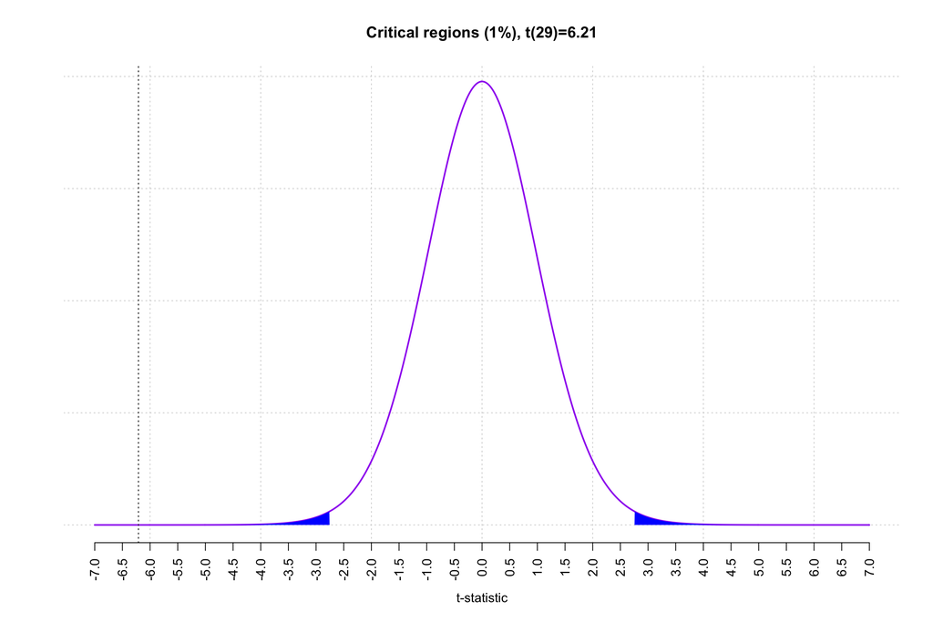

## Making a decision

We reject the null hypothesis of $H0: \mu_{D}=0$.

*The difference in the outlook on the future score was significantly smaller than 0 ($M_D = -1.49$, $SD_D = 1.30$), $t(29)=-6.21$, $p < .01$. People reported a lower outlook on the future score in June 2020 ($M = 3.65$, $SD = 2.68$) than in June 2019 ($M = 5.14$, $SD = 0.96$)*

## In the live session

- step-wise example
- comparison of within vs between-subjects designs

## Recap

- repeated measures designs (or: within-subjects designs) measure the same sample twice
- we are therefore interested in the difference between the two measurements $\Delta = M_2-M_1$
- the logic follows the one-sample t-test

## Next week

Mid-term mock exam